# Kaggle: House Prices

Jessie Alwerdt

10/14/2020

# Using a Kaggle dataset: House Prices: Advanced Regression Techniques / Predict sales prices and practice feature engineering, RFs, and gradient boosting

# https://www.kaggle.com/c/house-prices-advanced-regression-techniques

## Packages to load

### Set working directory to obtain the train and test set

```r
setwd("C:/Users/alwer/Documents/Data Syndicate Projects DSS - FB group/Kaggle 1")
```

## Import the data

```r
train <- read.csv("train.csv", stringsAsFactors = F)
test <- read.csv("test.csv", stringsAsFactors = F)
```

# Data Cleaning

### View the structure and summary statistics of the train data set

```r
str(train)
```

```
## 'data.frame':    1460 obs. of  81 variables:
##  $ Id           : int  1 2 3 4 5 6 7 8 9 10 ...
##  $ MSSubClass   : int  60 20 60 70 60 50 20 60 50 190 ...
##  $ MSZoning     : chr  "RL" "RL" "RL" "RL" ...
##  $ LotFrontage  : int  65 80 68 60 84 85 75 NA 51 50 ...
##  $ LotArea      : int  8450 9600 11250 9550 14260 14115 10084 10382 6120 7420 ...
##  $ Street       : chr  "Pave" "Pave" "Pave" "Pave" ...
##  $ Alley        : chr  NA NA NA NA ...
##  $ LotShape     : chr  "Reg" "Reg" "IR1" "IR1" ...
##  $ LandContour  : chr  "Lvl" "Lvl" "Lvl" "Lvl" ...
##  $ Utilities    : chr  "AllPub" "AllPub" "AllPub" "AllPub" ...
##  $ LotConfig    : chr  "Inside" "FR2" "Inside" "Corner" ...
##  $ LandSlope    : chr  "Gtl" "Gtl" "Gtl" "Gtl" ...
##  $ Neighborhood : chr  "CollgCr" "Veenker" "CollgCr" "Crawfor" ...
##  $ Condition1   : chr  "Norm" "Feedr" "Norm" "Norm" ...
```

[output cut: 67 more lines]

```r
summary(train)
```

```
##        Id           MSSubClass      MSZoning          LotFrontage
##  Min.   :   1.0   Min.   : 20.0   Length:1460        Min.   : 21.00
##  1st Qu.: 365.8   1st Qu.: 20.0   Class :character   1st Qu.: 59.00
##  Median : 730.5   Median : 50.0   Mode  :character   Median : 69.00
##  Mean   : 730.5   Mean   : 56.9                      Mean   : 70.05
##  3rd Qu.:1095.2   3rd Qu.: 70.0                      3rd Qu.: 80.00
##  Max.   :1460.0   Max.   :190.0                      Max.   :313.00
##                                                      NA's   :259
##     LotArea          Street             Alley             LotShape
##  Min.   :  1300   Length:1460        Length:1460        Length:1460
##  1st Qu.:  7554   Class :character   Class :character   Class :character
##  Median :  9478   Mode  :character   Mode  :character   Mode  :character
##  Mean   : 10517
##  3rd Qu.: 11602
##  Max.   :215245
##
##  LandContour         Utilities          LotConfig          LandSlope
##  Length:1460        Length:1460        Length:1460        Length:1460
##  Class :character   Class :character   Class :character   Class :character
##  Mode  :character   Mode  :character   Mode  :character   Mode  :character
##
##
##
##
##  Neighborhood        Condition1         Condition2          BldgType
##  Length:1460        Length:1460        Length:1460        Length:1460
##  Class :character   Class :character   Class :character   Class :character
##  Mode  :character   Mode  :character   Mode  :character   Mode  :character
##
##
##
##
##   HouseStyle         OverallQual      OverallCond      YearBuilt
##  Length:1460        Min.   : 1.000   Min.   :1.000   Min.   :1872
##  Class :character   1st Qu.: 5.000   1st Qu.:5.000   1st Qu.:1954
##  Mode  :character   Median : 6.000   Median :5.000   Median :1973
##                     Mean   : 6.099   Mean   :5.575   Mean   :1971
##                     3rd Qu.: 7.000   3rd Qu.:6.000   3rd Qu.:2000
##                     Max.   :10.000   Max.   :9.000   Max.   :2010
##
```

[output cut: 113 more lines]

```
##  Min.   : 1.000   Min.   :2006   Length:1460        Length:1460
##  1st Qu.: 5.000   1st Qu.:2007   Class :character   Class :character
##  Median : 6.000   Median :2008   Mode  :character   Mode  :character
##  Mean   : 6.322   Mean   :2008
##  3rd Qu.: 8.000   3rd Qu.:2009
##  Max.   :12.000   Max.   :2010
##
##    SalePrice
##  Min.   : 34900
##  1st Qu.:129975
##  Median :163000
##  Mean   :180921
##  3rd Qu.:214000
##  Max.   :755000
##
```

### Variables that need to be changed to categorical:

- MSSubClass
- Shape
- LandContour
- Utilities
- LotConfig
- LandSlope
- Neighborhood
- Condition1
- Condition2
- BldgType
- HouseStyle
- RoofStyle
- RoofMatl
- Exterior1st
- Exterior2nd
- MasVnrType
- ExterQual
- ExterCond
- Foundation
- BsmtQual
- BsmtCond
- BsmtExposure
- BsmtFinType1
- BsmtFinType2
- Heating
- HeatingQC
- CentralAir
- Electrical
- BsmtFullBath
- BsmtHalfBath
- FullBath
- HalfBath
- BedroomAbvGr
- KitchenAbvGr
- KitchenQual
- Functional
- TotRmsAbvGrd
- Fireplaces
- FireplaceQu
- GarageType
- GarageFinish
- GarageQual
- GarageCond
- PavedDrive
- PoolQC
- Fence
- MiscFeature
- SaleType
- SaleCondition
- GarageCars
- MoSold

```r
train <- train %>%
  mutate_at(vars(MSSubClass, MSZoning, Street, Alley, LotShape, LandContour, Utilities, LotConfig, LandSlope, Neighborhood, Condition1, Condition2, BldgType, HouseStyle, RoofStyle, RoofMatl, Exterior1st, Exterior2nd, MasVnrType, ExterQual, ExterCond, Foundation, BsmtQual, BsmtCond, BsmtExposure, BsmtFinType1, BsmtFinType2, Heating, HeatingQC, CentralAir, Electrical,  BsmtFullBath, BsmtHalfBath, FullBath, HalfBath, BedroomAbvGr, KitchenAbvGr, KitchenQual, Functional, TotRmsAbvGrd, Fireplaces, FireplaceQu, GarageType, GarageFinish, GarageQual, GarageCond, PavedDrive, PoolQC, Fence, MiscFeature, SaleType, SaleCondition, GarageCars, MoSold), factor)
```

### Variables that need to be changed to ordinal

- OverallQual
- OverallCond

```r
train <- train %>%
  mutate_at(vars(OverallQual, OverallCond), factor, ordered = TRUE)
```

### Repeat on the test set

```r
test <- test %>%
  mutate_at(vars(MSSubClass, MSZoning, Street, Alley, LotShape, LandContour, Utilities, LotConfig, LandSlope, Neighborhood, Condition1, Condition2, BldgType, HouseStyle, RoofStyle, RoofMatl, Exterior1st, Exterior2nd, MasVnrType, ExterQual, ExterCond, Foundation, BsmtQual, BsmtCond, BsmtExposure, BsmtFinType1, BsmtFinType2, Heating, HeatingQC, CentralAir, Electrical,  BsmtFullBath, BsmtHalfBath, FullBath, HalfBath, BedroomAbvGr, KitchenAbvGr, KitchenQual, Functional, TotRmsAbvGrd, Fireplaces, FireplaceQu, GarageType, GarageFinish, GarageQual, GarageCond, PavedDrive, PoolQC, Fence, MiscFeature, SaleType, SaleCondition, GarageCars, MoSold), factor)
```

```r
test<- test %>%
  mutate_at(vars(OverallQual, OverallCond), factor, ordered = TRUE)
```

```r
str(test)
```

```
## 'data.frame':    1459 obs. of  80 variables:
##  $ Id           : int  1461 1462 1463 1464 1465 1466 1467 1468 1469 1470 ...
##  $ MSSubClass   : Factor w/ 16 levels "20","30","40",..: 1 1 6 6 12 6 1 6 1 1 ...
##  $ MSZoning     : Factor w/ 5 levels "C (all)","FV",..: 3 4 4 4 4 4 4 4 4 4 ...
##  $ LotFrontage  : int  80 81 74 78 43 75 NA 63 85 70 ...
##  $ LotArea      : int  11622 14267 13830 9978 5005 10000 7980 8402 10176 8400 ...
##  $ Street       : Factor w/ 2 levels "Grvl","Pave": 2 2 2 2 2 2 2 2 2 2 ...
##  $ Alley        : Factor w/ 2 levels "Grvl","Pave": NA NA NA NA NA NA NA NA NA NA ...
##  $ LotShape     : Factor w/ 4 levels "IR1","IR2","IR3",..: 4 1 1 1 1 1 1 1 4 4 ...
##  $ LandContour  : Factor w/ 4 levels "Bnk","HLS","Low",..: 4 4 4 4 2 4 4 4 4 4 ...
##  $ Utilities    : Factor w/ 1 level "AllPub": 1 1 1 1 1 1 1 1 1 1 ...
##  $ LotConfig    : Factor w/ 5 levels "Corner","CulDSac",..: 5 1 5 5 5 1 5 5 5 1 ...
##  $ LandSlope    : Factor w/ 3 levels "Gtl","Mod","Sev": 1 1 1 1 1 1 1 1 1 1 ...
##  $ Neighborhood : Factor w/ 25 levels "Blmngtn","Blueste",..: 13 13 9 9 22 9 9 9 9 13 ...
##  $ Condition1   : Factor w/ 9 levels "Artery","Feedr",..: 2 3 3 3 3 3 3 3 3 3 ...
```

[output cut: 66 more lines]

### Make a new variable that is the age of the house (year sold - year built)

```r
train$House_Age <- train$YrSold - train$YearBuilt
test$House_Age <- test$YrSold - test$YearBuilt
```

### Now that new variables were calculated, make year sold into a factor variable

```r
train <- train %>%
  mutate_at(vars(YrSold), factor)

test <- test %>%
  mutate_at(vars(YrSold), factor)
```

### Check to see if properly coverted

```r
str(train$YrSold)
```

```
##  Factor w/ 5 levels "2006","2007",..: 3 2 3 1 3 4 2 4 3 3 ...
```

```r
str(test$YrSold)
```

```
##  Factor w/ 5 levels "2006","2007",..: 5 5 5 5 5 5 5 5 5 5 ...
```

### Create an interactive plot of the variables using ‘DataExplorer’ R package

- Cui, B. (2020). DataExplorer: Automate Data Exploration and Treatment (0.8.1) [Computer software]. https://CRAN.R-project.org/package=DataExplorer

```r
data_list <- list(train)
plot_str(data_list, type = "r")
```

# Missing Data

### Examine the amount of missing data in the train and test data sets

- There are 5.8% missing observations in the train data set
- There are 5.9% missing observations in the test data set

```r
introduce(train)
```

```
##   rows columns discrete_columns continuous_columns all_missing_columns
## 1 1460      82               57                 25                   0
##   total_missing_values complete_rows total_observations memory_usage
## 1                 6965             0             119720       540944
```

```r
introduce(test)
```

```
##   rows columns discrete_columns continuous_columns all_missing_columns
## 1 1459      81               57                 24                   0
##   total_missing_values complete_rows total_observations memory_usage
## 1                 7000             0             118179       533920
```

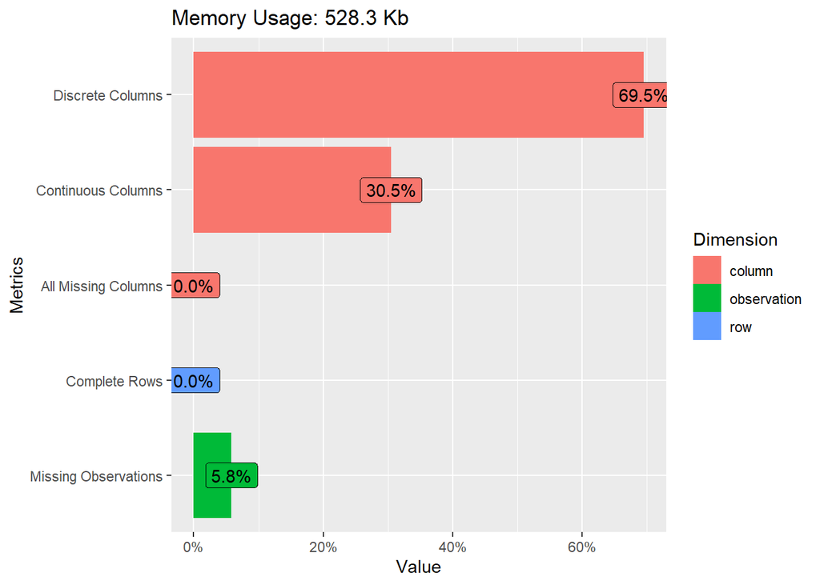

Examine Missing Data in Both the Train and Test Sets

```r
plot_intro(train)
```

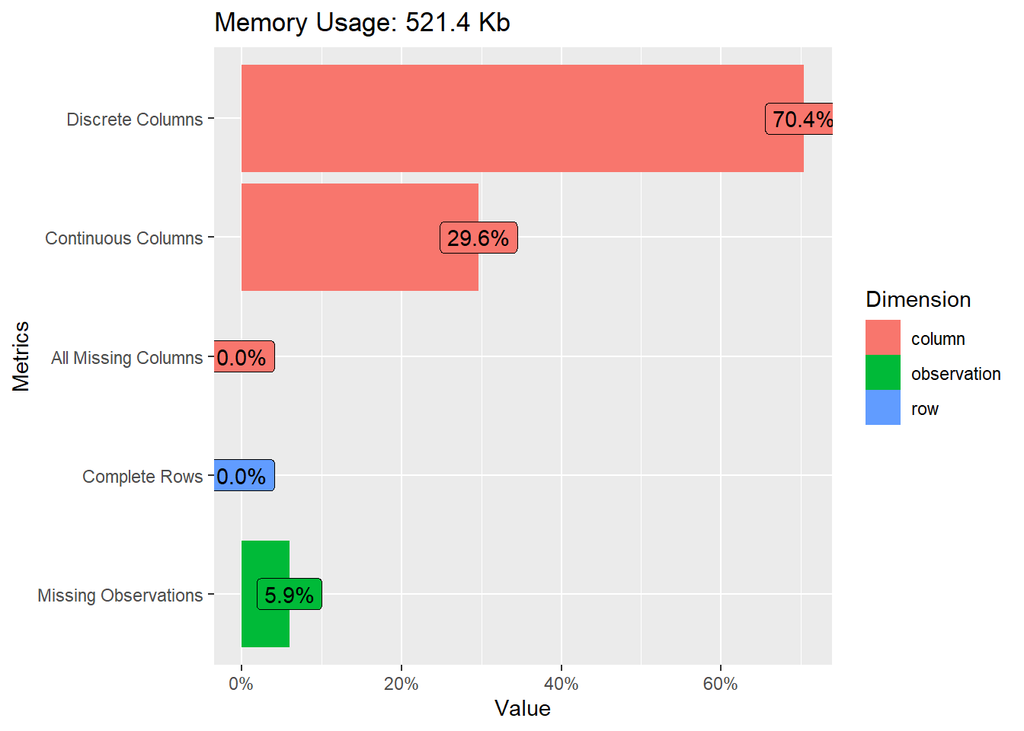

Examine Missing Data in Both the Train and Test Sets

```r
plot_intro(test)
```

### Plot missing values for the train set

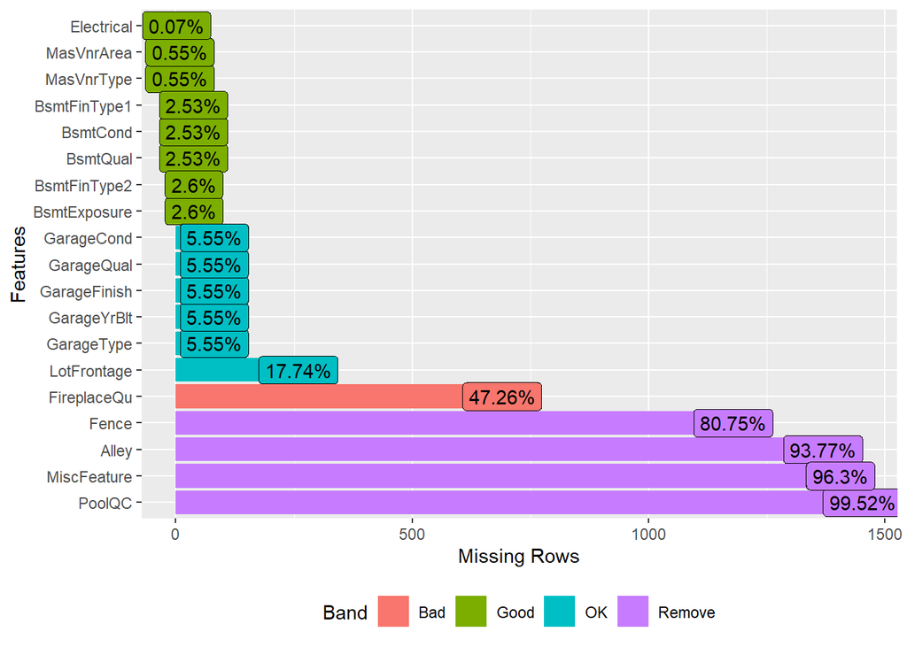

```r
plot_missing(train, missing_only = TRUE)
```

### Plot missing values for the test set

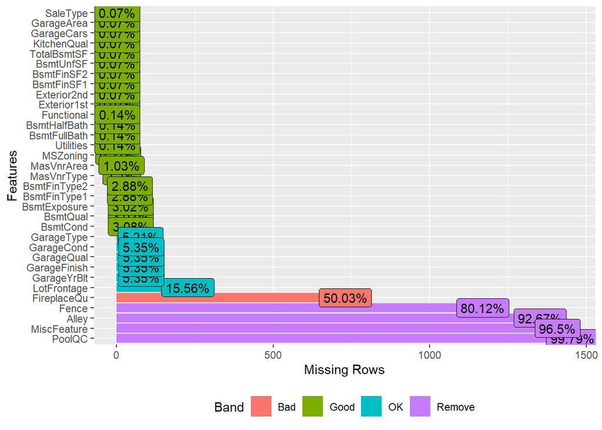

```r
plot_missing(test, missing_only = TRUE)
```

### Indicated above, the test set has more variables with missing data compared to the train data set. The test set will have to be further examined for preparation.

### Examine missing data patterns and see if they are missing at random

### Tools are great for smaller data sets but was hard to pick up patterns with so many variables

### Keep the list of explanatory variables in case they are needed in the future

### Get rid of alley / MiscFeature / PoolQC / Utilities is only 1 factor - delete

```r
train_clean <- select(train, -c(PoolQC, Alley, MiscFeature, Utilities))
test_clean <- select(test, -c(PoolQC, Alley, MiscFeature, Utilities))
```

### Check to see if they were deleted properly

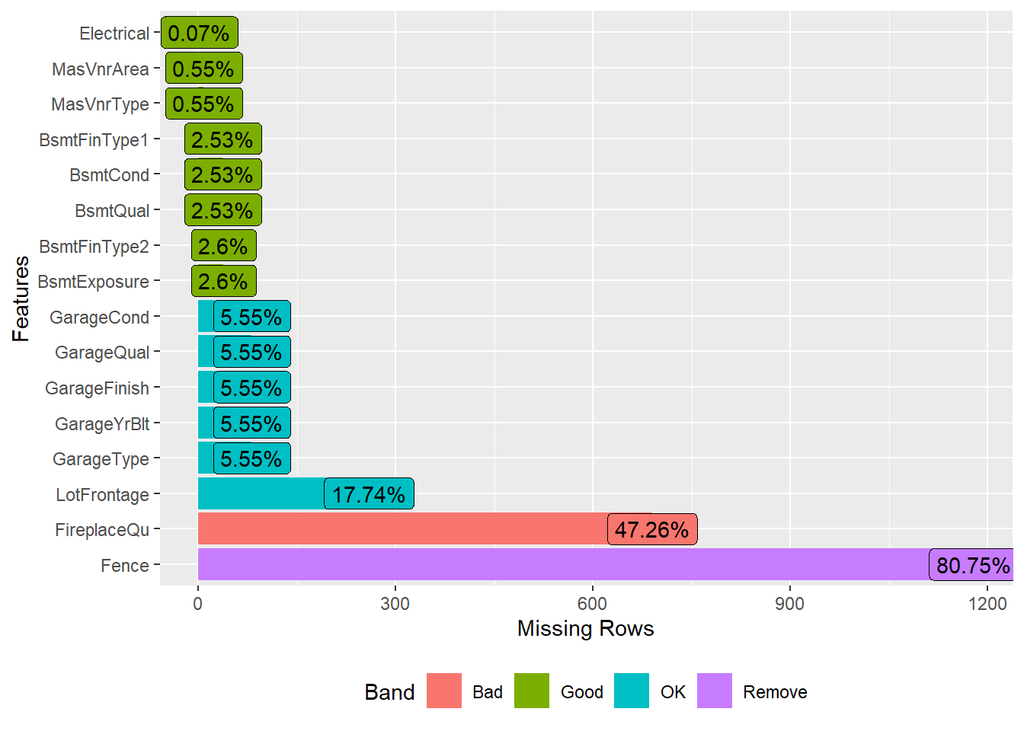

```r
plot_missing(train_clean, missing_only = TRUE)
```

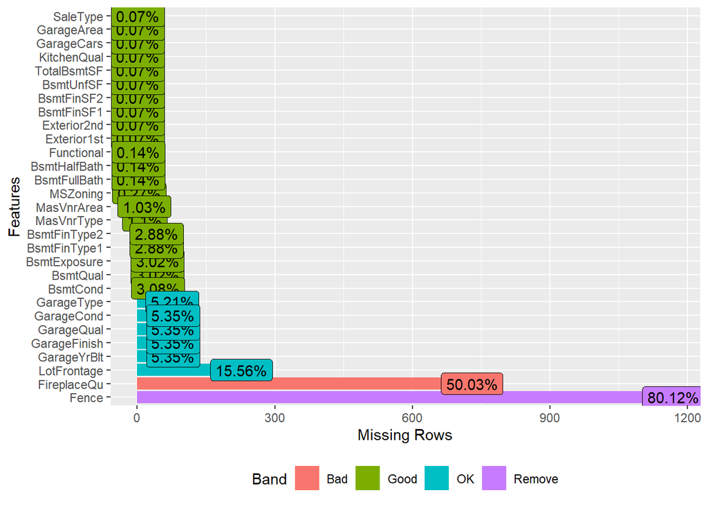

```r
plot_missing(test_clean, missing_only = TRUE)
```

### Correct variables where NA is actually “None” or numerical 0

```r
train_clean2 <- train_clean %>%
  mutate(FireplaceQu = as.character(FireplaceQu), Fence = as.character(Fence), BsmtExposure = as.character(BsmtExposure), BsmtFinType2 = as.character(BsmtFinType2), BsmtQual = as.character(BsmtQual), BsmtCond = as.character(BsmtCond), BsmtFinType1 = as.character(BsmtFinType1), GarageType = as.character(GarageType), GarageFinish = as.character(GarageFinish), GarageQual = as.character(GarageQual), GarageCond = as.character(GarageCond)) %>%
  replace_na(list(FireplaceQu = "None", Fence = "None", BsmtExposure = "None", BsmtFinType2 = "None", BsmtQual = "None", BsmtCond = "None", BsmtFinType1 = "None", GarageType = "None", GarageFinish = "None", GarageQual = "None", GarageCond = "None", LotFrontage = 0, BsmtFinSF1 = 0, BsmtFinSF2 = 0, BsmtUnfSF = 0, TotalBsmtSF = 0)) %>%
  mutate(FireplaceQu = as.factor(FireplaceQu), Fence = as.factor(Fence), BsmtExposure = as.factor(BsmtExposure), BsmtFinType2 = as.factor(BsmtFinType2), BsmtQual = as.factor(BsmtQual), BsmtCond = as.factor(BsmtCond), BsmtFinType1 = as.factor(BsmtFinType1), GarageType = as.factor(GarageType), GarageFinish = as.factor(GarageFinish), GarageQual = as.factor(GarageQual), GarageCond = as.factor(GarageCond), GarageArea = as.numeric(GarageArea), SalePrice = as.numeric(SalePrice))

test_clean2 <- test_clean %>%
  mutate(FireplaceQu = as.character(FireplaceQu), Fence = as.character(Fence), BsmtExposure = as.character(BsmtExposure), BsmtFinType2 = as.character(BsmtFinType2), BsmtQual = as.character(BsmtQual), BsmtCond = as.character(BsmtCond), BsmtFinType1 = as.character(BsmtFinType1), GarageType = as.character(GarageType), GarageFinish = as.character(GarageFinish), GarageQual = as.character(GarageQual), GarageCond = as.character(GarageCond)) %>%
  replace_na(list(FireplaceQu = "None", Fence = "None", BsmtExposure = "None", BsmtFinType2 = "None", BsmtQual = "None", BsmtCond = "None", BsmtFinType1 = "None", GarageType = "None", GarageFinish = "None", GarageQual = "None", GarageCond = "None", LotFrontage = 0, BsmtFinSF1 = 0, BsmtFinSF2 = 0, BsmtUnfSF = 0, TotalBsmtSF = 0)) %>%
  mutate(FireplaceQu = as.factor(FireplaceQu), Fence = as.factor(Fence), BsmtExposure = as.factor(BsmtExposure), BsmtFinType2 = as.factor(BsmtFinType2), BsmtQual = as.factor(BsmtQual), BsmtCond = as.factor(BsmtCond), BsmtFinType1 = as.factor(BsmtFinType1), GarageType = as.factor(GarageType), GarageFinish = as.factor(GarageFinish), GarageQual = as.factor(GarageQual), GarageCond = as.factor(GarageCond), GarageArea = as.numeric(GarageArea))
```

### Examine missing again and make sure variables that are left are truly missing and will be imputed

```r
introduce(train_clean2)
```

```
##   rows columns discrete_columns continuous_columns all_missing_columns
## 1 1460      78               53                 25                   0
##   total_missing_values complete_rows total_observations memory_usage
## 1                   98          1370             113880       556176
```

```r
introduce(test_clean2)
```

```
##   rows columns discrete_columns continuous_columns all_missing_columns
## 1 1459      77               53                 24                   0
##   total_missing_values complete_rows total_observations memory_usage
## 1                  125          1357             112343       543472
```

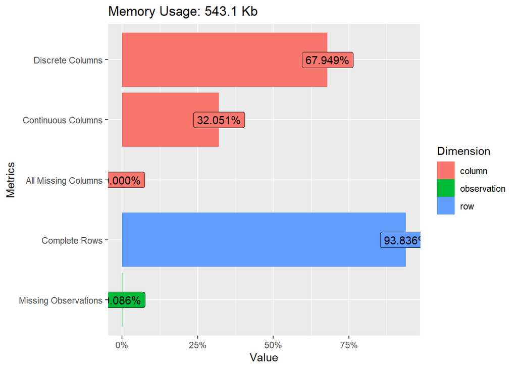

```r
plot_intro(train_clean2)
```

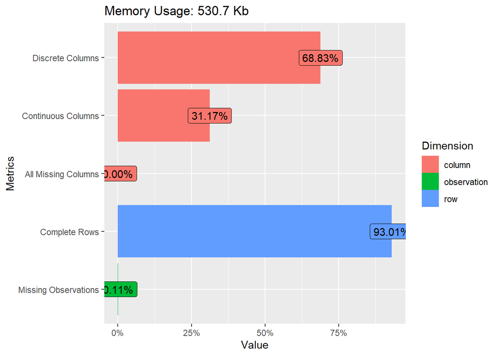

```r
plot_intro(test_clean2)
```

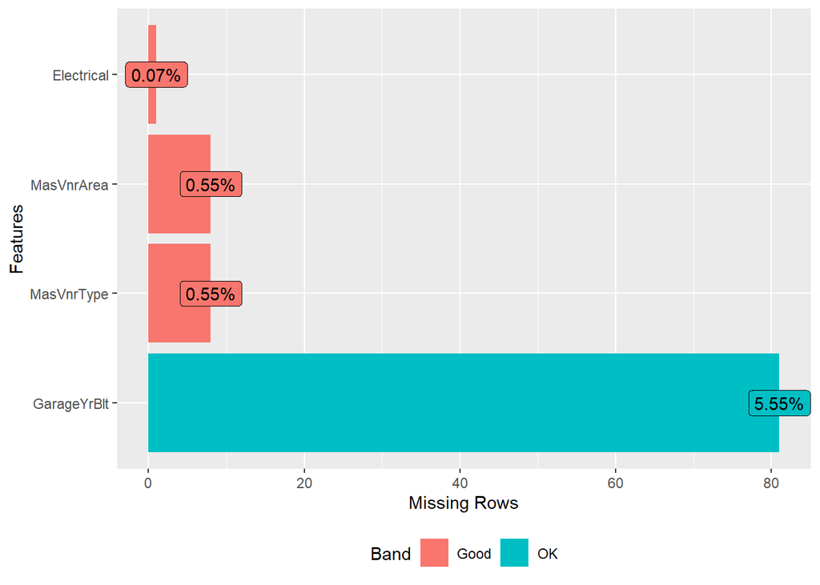

```r
plot_missing(train_clean2, missing_only = TRUE)
```

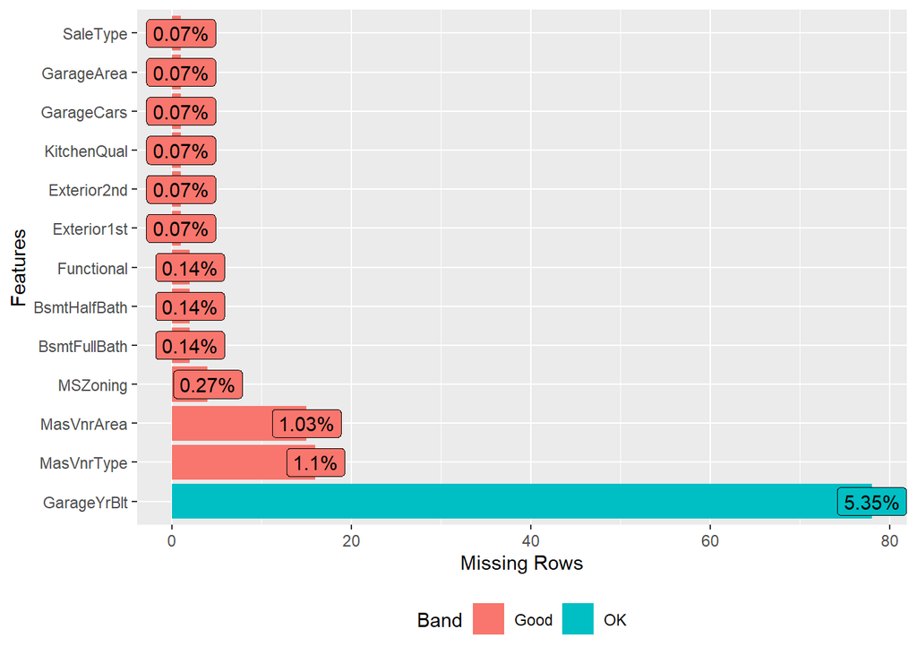

```r
plot_missing(test_clean2, missing_only = TRUE)
```

# Use Imputation with the ‘missForest’ R Package.This R package is known to work well on mixed-type data.

- Stekhoven, D. J. (2013). missForest: Nonparametric Missing Value Imputation using Random Forest (1.4) [Computer software]. https://CRAN.R-project.org/package=missForest
- Dávila, S., & Rosado, H. (2017). Performance of missing value imputation schemes in health-related data. IIE Annual Conference. Proceedings; Norcross, 2105–2110.
- Stekhoven, D. J., & Bühlmann, P. (2012). MissForest—Non-parametric missing value imputation for mixed-type data. Bioinformatics, 28(1), 112–118. https://doi.org/10.1093/bioinformatics/btr597
- Waljee, A. K., Mukherjee, A., Singal, A. G., Zhang, Y., Warren, J., Balis, U., Marrero, J., Zhu, J., & Higgins, P. D. (2013). Comparison of imputation methods for missing laboratory data in medicine. BMJ Open, 3(8), e002847. https://doi.org/10.1136/bmjopen-2013-002847
- Wei, R., Wang, J., Su, M., Jia, E., Chen, T., & Ni, Y. (2017). Missing Value Imputation Approach for Mass Spectrometry-based Metabolomics Data. BioRxiv, 171967. https://doi.org/10.1101/171967

### Impute missing vars from MSZoning, Functional, Exterior1st, Exterior2nd, KitchenQual, GarageCars, GarageArea, SaleType, BsmtFullBath, and BsmtHalfBath

```r
registerDoParallel(cores = 4)

set.seed(8374)

#Used to establish ntree of 500, mtry = 100 due to high-dimensional data and parallelize
train.imp <- missForest(train_clean2, verbose = FALSE, parallelize = "variables")
```

```
##   missForest iteration 1 in progress...done!
##   missForest iteration 2 in progress...done!
##   missForest iteration 3 in progress...done!
##   missForest iteration 4 in progress...done!
##   missForest iteration 5 in progress...done!
##   missForest iteration 6 in progress...done!
##   missForest iteration 7 in progress...done!
##   missForest iteration 8 in progress...done!
##   missForest iteration 9 in progress...done!
```

```r
train.imp$OOBerror
```

```
##        NRMSE          PFC
## 0.0006072588 0.0029416950
```

### Now impute on the test set. Did not combine the train and test set together because the test set is supposed to be completely untouched and avoid any data leakage.

```r
set.seed(8374)
#Used to establish ntree of 500, mtry = 100 due to high-dimensional data and parallelize
test.imp <- missForest(test_clean2, verbose = FALSE, parallelize = "variables")
```

```
##   missForest iteration 1 in progress...done!
##   missForest iteration 2 in progress...done!
##   missForest iteration 3 in progress...done!
##   missForest iteration 4 in progress...done!
##   missForest iteration 5 in progress...done!
##   missForest iteration 6 in progress...done!
##   missForest iteration 7 in progress...done!
##   missForest iteration 8 in progress...done!
```

```r
test.imp$OOBerror
```

```
##      NRMSE        PFC
## 0.01344836 0.02195492
```

### Save each imputed data set

```r
write.csv(train.imp[["ximp"]], file = "train_imp.csv")
write.csv(test.imp[["ximp"]], file = "test_imp.csv")
```

### Bring data back in

```r
train_imputed <- train.imp[["ximp"]]
test_imputed <- test.imp[["ximp"]]
```

### Check to see if all missing data has been imputated

```r
introduce(train_imputed)
```

```
##   rows columns discrete_columns continuous_columns all_missing_columns
## 1 1460      78               53                 25                   0
##   total_missing_values complete_rows total_observations memory_usage
## 1                    0          1460             113880       567856
```

```r
introduce(test_imputed)
```

```
##   rows columns discrete_columns continuous_columns all_missing_columns
## 1 1459      77               53                 24                   0
##   total_missing_values complete_rows total_observations memory_usage
## 1                    0          1459             112343       555136
```

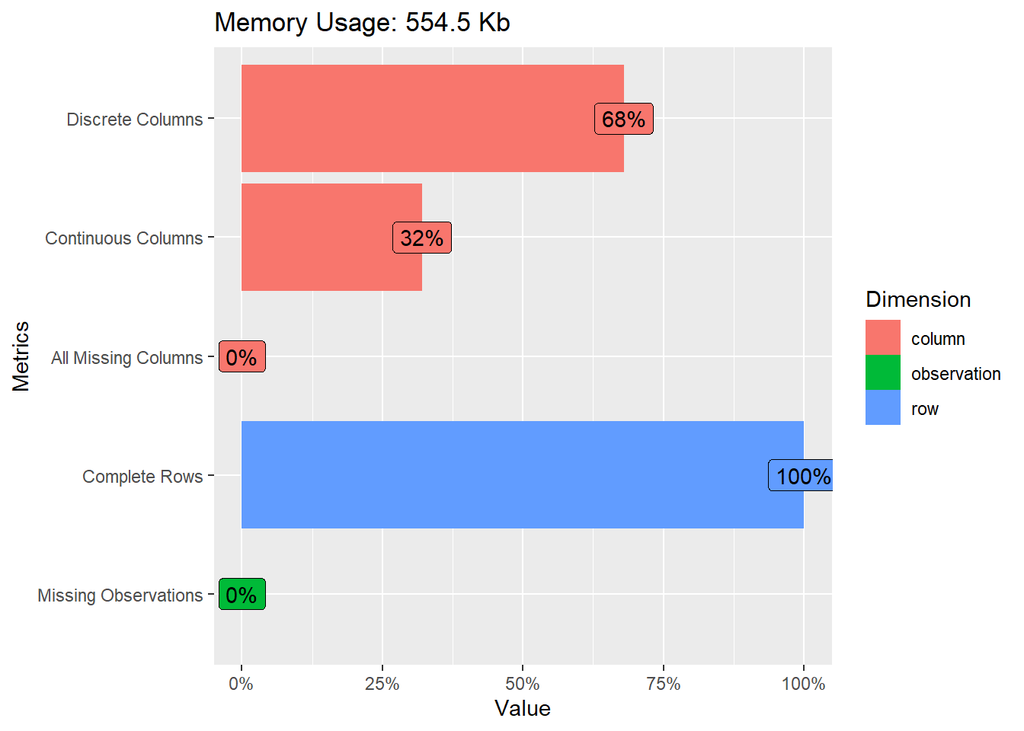

Checking Missing Data in the Newly Imputated Data Sets

```r
plot_intro(train_imputed)
```

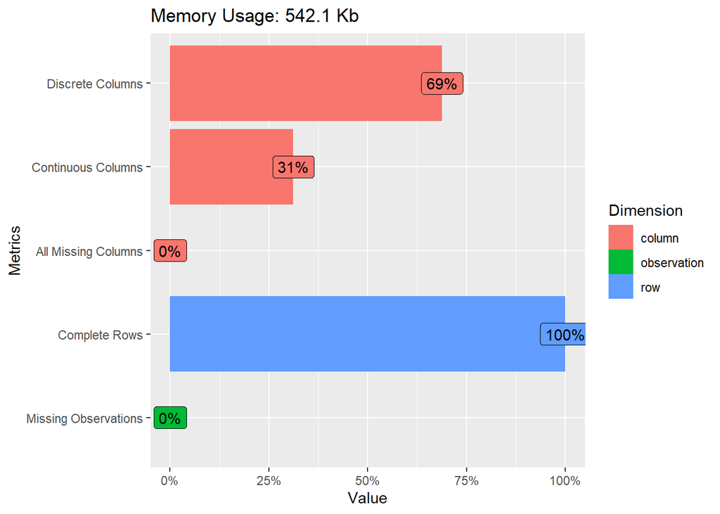

Checking Missing Data in the Newly Imputated Data Sets

```r
plot_intro(test_imputed)
```

### Check factors and numerical data types

### Make sure that the train and test data sets have the same variables and variable types

```r
comparedf(train_imputed, test_imputed)
```

```
## Compare Object
##
## Function Call:
## comparedf(x = train_imputed, y = test_imputed)
##
## Shared: 77 non-by variables and 1459 observations.
## Not shared: 1 variables and 1 observations.
##
## Differences found in 77/77 variables compared.
## 15 variables compared have non-identical attributes.
```

# Use Vtreat to deal with the categorical data which will turn these variables into numeric variables. This will also allow for any model to handle the data.

- Mount, J., Zumel, N., & LLC, W.-V. (2020). vtreat: A Statistically Sound “data.frame” Processor/Conditioner (1.6.1) [Computer software]. https://CRAN.R-project.org/package=vtreat

```r
set.seed(1847)

train_prepared <- mkCrossFrameNExperiment(
  dframe = train_imputed,
  varlist = setdiff(colnames(train_imputed), 'SalePrice'),
  outcomename = 'SalePrice',
  verbose = FALSE,
  rareCount = 5,
  rareSig=c())
```

```r
plan <- train_prepared$treatments

# get the performance statistics on the derived variables.
sf <- train_prepared$treatments$scoreFrame

# get the simulated out of sample transformed training data.frame

treatedTrain <- train_prepared$crossFrame
```

### Get newvars to keep

```r
newVars <- sf$varName[sf$sig<1/nrow(sf)]
```

### In future models, as.formula(f) will be used to get the recommended variables from vtreat (f will be the filter)

```r
f <- paste('SalePrice',
          paste(newVars, collapse = ' + '),
          sep = ' ~ ')

f <- noquote(f)

f <- as.formula(f)
```

### Make a new dataset with the new variables only

```r
treatedTrain <- treatedTrain[c(newVars, "SalePrice")]
```

### Will also apply to test set

```r
treatedTest <- vtreat::prepare(plan, test_imputed,
                               pruneSig = NULL,
                               varRestriction = newVars)
```

### Now have treatedTrain and treatedTest for future models

### Check to find differences between the two new prepared datasets (test_prepared and train_prepared)

### Make sure that the train and test data sets have the same variables and variable types

```r
comparedf(treatedTrain, treatedTest)
```

```
## Compare Object
##
## Function Call:
## comparedf(x = treatedTrain, y = treatedTest)
##
## Shared: 305 non-by variables and 1459 observations.
## Not shared: 1 variables and 1 observations.
##
## Differences found in 305/305 variables compared.
## 0 variables compared have non-identical attributes.
```

## Check the skewness of the outcome variable ‘SalePrice’

```r
skew(treatedTrain$SalePrice)
```

```
## [1] 1.879009
```

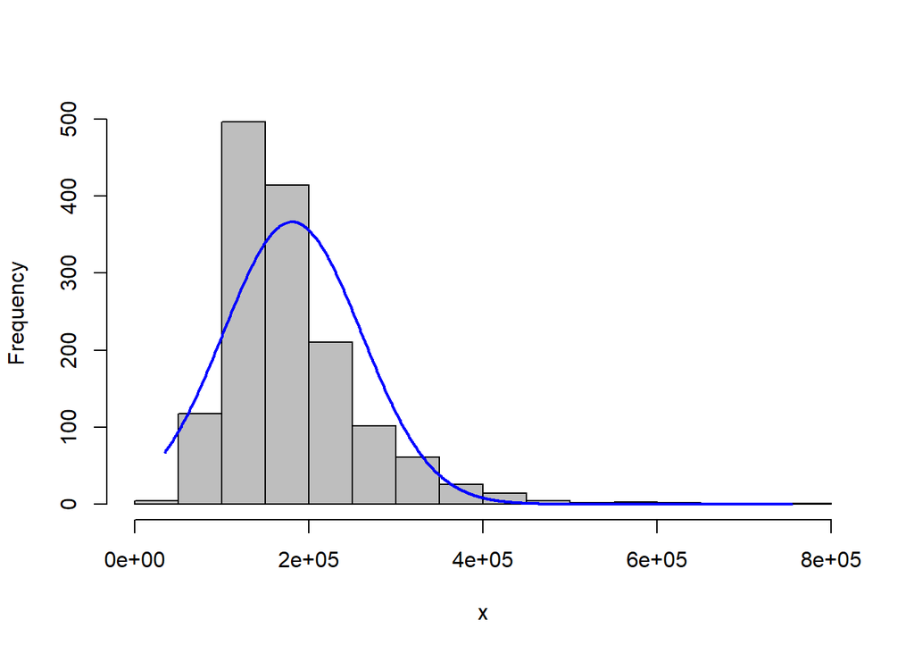

Describe SalePrice

```r
rcompanion::plotNormalHistogram(treatedTrain$SalePrice)
```

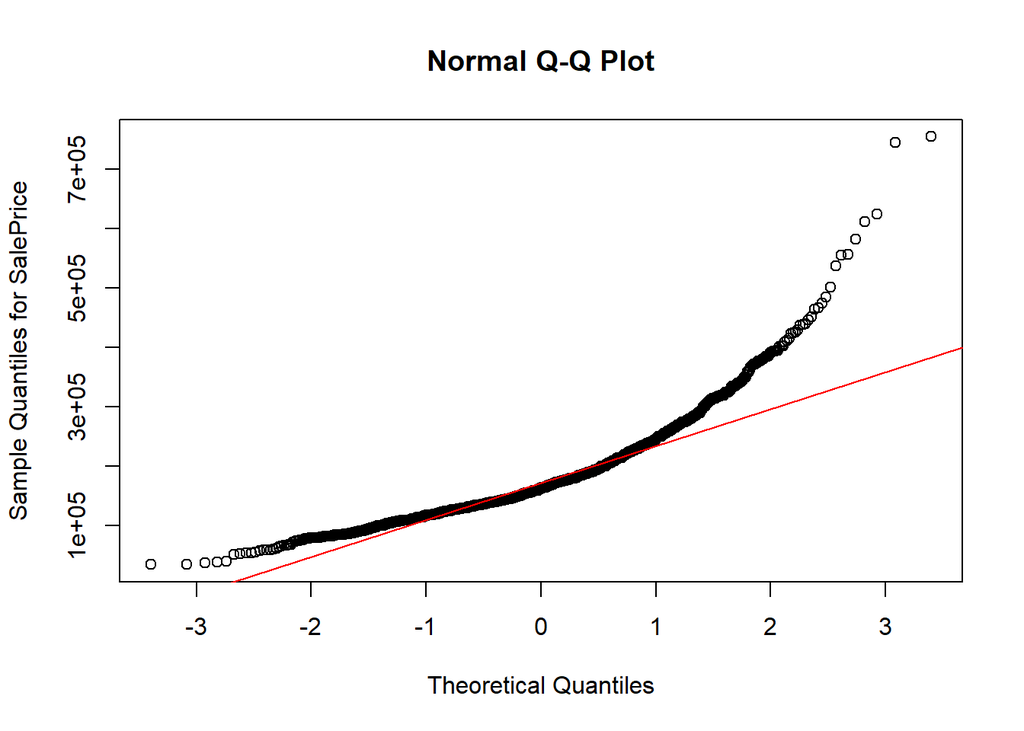

Describe SalePrice

```r
qqnorm(treatedTrain$SalePrice, ylab = "Sample Quantiles for SalePrice")
qqline(treatedTrain$SalePrice, col = "red")
```

### It is evident that the outcome variable is rightly skewed.

### Therefore, apply a log transformation and plot again.

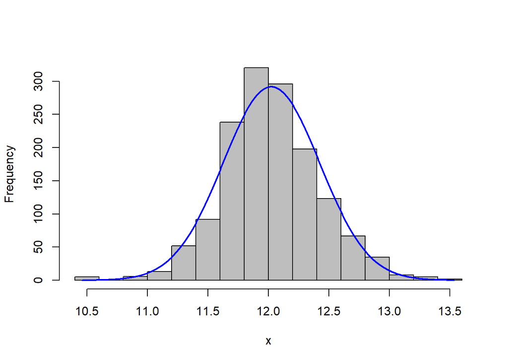

```r
treatedTrain$SalePrice <- log(treatedTrain$SalePrice)

rcompanion::plotNormalHistogram(treatedTrain$SalePrice)
```

- Ryu, C. (2020). dlookr: Tools for Data Diagnosis, Exploration, Transformation (0.3.13) [Computer software]. https://CRAN.R-project.org/package=dlookr

## Going to replace any outliers by winsorizing the values

```r
treatedTrain_matrix <- data.matrix(treatedTrain)

winsorize_data <- Winsorize(treatedTrain_matrix)
```

### Revert back to a data frame

```r
treatedTrain <- as.data.frame(winsorize_data)
```

### Do the same for the test data

```r
treatedTest_matrix <- data.matrix(treatedTest)

winsorize_data_test <- Winsorize(treatedTest_matrix, na.rm = TRUE)
```

```r
treatedTest <- as.data.frame(winsorize_data_test)
```

# Data is prepared: Baseline Testing

### Time for some baseline testing

```r
# Baseline model - predict the mean of the training data
best.guess <- mean(treatedTrain$SalePrice)

best.guess
```

```
## [1] 12.02405
```

```r
RMSE.baseline_train <- sqrt(mean((best.guess-treatedTrain$SalePrice)^2))

RMSE.baseline_train
```

```
## [1] 0.399315
```

```r
MSE.baseline_train <- (mean((best.guess-treatedTrain$SalePrice)^2))
MSE.baseline_train
```

```
## [1] 0.1594525
```

```r
MAE.baseline_train <- mean(abs(best.guess-treatedTrain$SalePrice))
MAE.baseline_train
```

```
## [1] 0.3098117
```

# Use caret to try several different models and tune

- Kuhn, M., Wing, J., Weston, S., Williams, A., Keefer, C., Engelhardt, A., Cooper, T., Mayer, Z., Kenkel, B., R Core Team, Benesty, M., Lescarbeau, R., Ziem, A., Scrucca, L., Tang, Y., Candan, C., & Hunt, T. (2020). caret: Classification and Regression Training (6.0-86) [Computer software]. https://CRAN.R-project.org/package=caret

## Start with an empty model to get an idea of improvement.

```
## Non-Informative Model
##
## 1460 samples
##  305 predictor
##
## Pre-processing: centered (305), scaled (305)
## Resampling: Cross-Validated (5 fold, repeated 5 times)
## Summary of sample sizes: 1167, 1169, 1169, 1166, 1169, 1168, ...
## Resampling results:
##
##   RMSE       Rsquared  MAE
##   0.3991597  NaN       0.309816
```

## ‘party’ R package

- Hothorn, T., Hornik, K., Strobl, C., & Zeileis, A. (2020). party: A Laboratory for Recursive Partytioning (1.3-5) [Computer software]. https://CRAN.R-project.org/package=party

```r
cl <- makeCluster(6)
registerDoParallel(cl)
opts <- list(preschedule=TRUE)
clusterSetRNGStream(cl, 5364)

train.control <- trainControl(
                           method = "repeatedcv",  number = 5,  repeats = 5, search = 'random')

tunegrid <- expand.grid(mtry = seq(3:10))

set.seed(93746)
SalePrice_cforest = train(
  SalePrice ~ .,
  data = treatedTrain,
  method = "cforest",
  preProc = c("center", "scale"),
  trControl = train.control,
  tuneLength  = 100,
  tuneGrid = tunegrid,
  metric='RMSE'
)

stopCluster(cl)

SalePrice_cforest
```

```
## Conditional Inference Random Forest
##
## 1460 samples
##  305 predictor
##
## Pre-processing: centered (305), scaled (305)
## Resampling: Cross-Validated (5 fold, repeated 5 times)
## Summary of sample sizes: 1167, 1169, 1169, 1166, 1169, 1168, ...
## Resampling results across tuning parameters:
##
##   mtry  RMSE       Rsquared   MAE
##   1     0.2622090  0.7598123  0.1877111
##   2     0.2157600  0.7883748  0.1504974
##   3     0.1965842  0.8067933  0.1356558
##   4     0.1862147  0.8189193  0.1274288
##   5     0.1796310  0.8269007  0.1226355
##   6     0.1754448  0.8320917  0.1194568
##   7     0.1725743  0.8358184  0.1174238
##   8     0.1700519  0.8391236  0.1155744
##
## RMSE was used to select the optimal model using the smallest value.
## The final value used for the model was mtry = 8.
```

## Using “gbm” R package

- Greenwell, B., Boehmke, B., Cunningham, J., & Developers (https://github.com/gbm-developers), G. B. M. (2020). gbm: Generalized Boosted Regression Models (2.1.8) [Computer software]. https://CRAN.R-project.org/package=gbm

```r
cl <- makeCluster(6)
registerDoParallel(cl)
opts <- list(preschedule=TRUE)
clusterSetRNGStream(cl, 5364)

train.control <- trainControl(
                           method = "repeatedcv",  number = 5,  repeats = 5, search = 'random')


set.seed(0394)

SalePrice_gbm = train(
  SalePrice ~ .,
  data = treatedTrain,
  method = "gbm",
  preProc = c("center", "scale"),
  trControl = train.control,
  #tuneLength  = 100,
  #tuneGrid = tunegrid,
  metric='RMSE'
)
```

```r
stopCluster(cl)

SalePrice_gbm
```

```
## Stochastic Gradient Boosting
##
## 1460 samples
##  305 predictor
##
## Pre-processing: centered (305), scaled (305)
## Resampling: Cross-Validated (5 fold, repeated 5 times)
## Summary of sample sizes: 1168, 1169, 1167, 1167, 1169, 1167, ...
## Resampling results across tuning parameters:
##
##   shrinkage   interaction.depth  n.minobsinnode  n.trees  RMSE       Rsquared
##   0.09407559  4                  15              3945     0.1334182  0.8895399
##   0.24716409  7                   8              3323     0.1452235  0.8699024
##   0.30483372  4                  12              2322     0.1494472  0.8630667
##   MAE
##   0.09180802
##   0.10259623
##   0.10692408
##
## RMSE was used to select the optimal model using the smallest value.
## The final values used for the model were n.trees = 3945, interaction.depth =
##  4, shrinkage = 0.09407559 and n.minobsinnode = 15.
```

## Use the “ranger” R Package

- Wright, M. N., Wager, S., & Probst, P. (2020). ranger: A Fast Implementation of Random Forests (0.12.1) [Computer software]. https://CRAN.R-project.org/package=ranger

```
## Random Forest
##
## 1460 samples
##  305 predictor
##
## Pre-processing: centered (305), scaled (305)
## Resampling: Cross-Validated (5 fold, repeated 5 times)
## Summary of sample sizes: 1168, 1169, 1168, 1167, 1168, 1169, ...
## Resampling results across tuning parameters:
##
##   min.node.size  mtry  splitrule   RMSE       Rsquared   MAE
##    4             179   extratrees  0.1475705  0.8674123  0.1010673
##    8             164   extratrees  0.1478831  0.8670018  0.1014096
##   14             144   variance    0.1419118  0.8773168  0.0963142
##
## RMSE was used to select the optimal model using the smallest value.
## The final values used for the model were mtry = 144, splitrule = variance
##  and min.node.size = 14.
```

## Use “glmnet” R package

- Friedman, J., Hastie, T., Tibshirani, R., Narasimhan, B., Tay, K., Simon, N., & Qian, J. (2020). glmnet: Lasso and Elastic-Net Regularized Generalized Linear Models (4.0-2) [Computer software]. https://CRAN.R-project.org/package=glmnet

```r
train.control <- trainControl(
                           method = "repeatedcv",  number = 5,  repeats = 5, search = 'random')

#tunegrid <- expand.grid(mtry = seq(3:10))

cl <- makeCluster(6)
registerDoParallel(cl)
opts <- list(preschedule=TRUE)
clusterSetRNGStream(cl, 2334)

SalePrice_glmnet = train(
  SalePrice ~ .,
  data = treatedTrain,
  method = "glmnet",
  preProc = c("center", "scale"),
  trControl = train.control,
  #tuneLength  = 100,
  #tuneGrid = tunegrid,
  metric='RMSE'
)

stopCluster(cl)

SalePrice_glmnet
```

```
## glmnet
##
## 1460 samples
##  305 predictor
##
## Pre-processing: centered (305), scaled (305)
## Resampling: Cross-Validated (5 fold, repeated 5 times)
## Summary of sample sizes: 1169, 1168, 1168, 1167, 1168, 1168, ...
## Resampling results across tuning parameters:
##
##   alpha      lambda       RMSE       Rsquared   MAE
##   0.3025126  0.001025421  0.1334156  0.8887215  0.08911097
##   0.6885703  0.004145984  0.1305692  0.8928874  0.08699152
##   0.7469319  0.828927762  0.3991763        NaN  0.30982340
##
## RMSE was used to select the optimal model using the smallest value.
## The final values used for the model were alpha = 0.6885703 and lambda
##  = 0.004145984.
```